# ANOVA

Szymon Szrajer

4 05 2021

## Zadanie 1

**Hipoteza robocza:**

Średnia długość jaj kukułki jest różna w gnieździe świergotka łąkowego i płochacza pokrzywnica.

**Hipoteza zerowa:**

Średnia długość jaj kukułki nie różni się w gnieździe świergotka łąkowego i płochacza pokrzywnica.

**Hipoteza alternatywna:**

Średnia długość jaj kukułki jest różna w gnieździe świergotka łąkowego i płochacza pokrzywnica.

**Testy “z wyboru”:**

Test t studenta dla prób niezależnych/ prosta analiza wariancji.

**Założenia teoretycznie dotyczące rozkładu wymagane dla wybranego testu:**

Rozkład zbliżony do normalnego. Niezależność losowa obserwacji. Równe wariancje.

**Statystyki opisowe:**

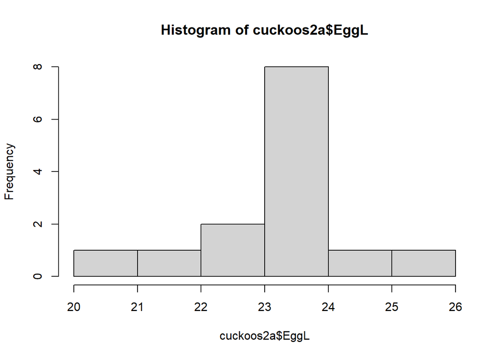

```r
cuckoos2 <- read.table(file = "Cuckoos_2.txt",
                        sep = "\t",
                        header = T,
                        stringsAsFactors = T)
cuckoos2a <- subset(cuckoos2,Species == "HS")
hist(cuckoos2a$EggL)
```

```r
summary(cuckoos2a$EggL)
```

```
##    Min. 1st Qu.  Median    Mean 3rd Qu.    Max.
##   20.85   22.90   23.05   23.12   23.85   25.05
```

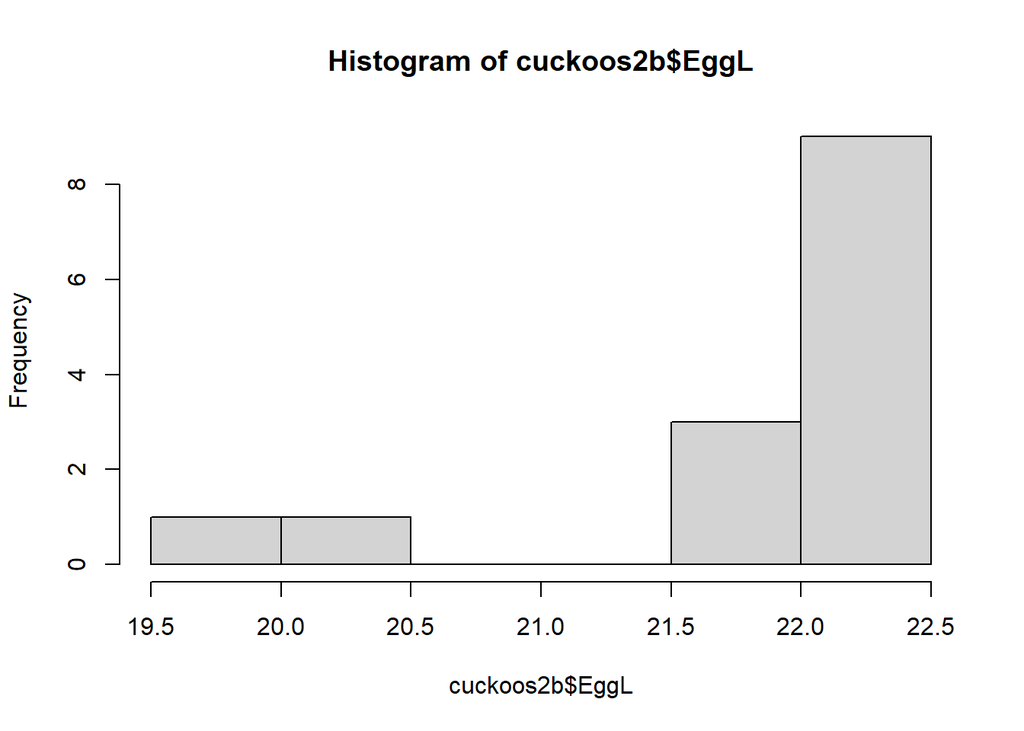

```r
cuckoos2b <- subset(cuckoos2,Species == "MP")
hist(cuckoos2b$EggL)
```

```r
summary(cuckoos2b$EggL)
```

```
##    Min. 1st Qu.  Median    Mean 3rd Qu.    Max.
##   19.65   21.85   22.05   21.76   22.20   22.45
```

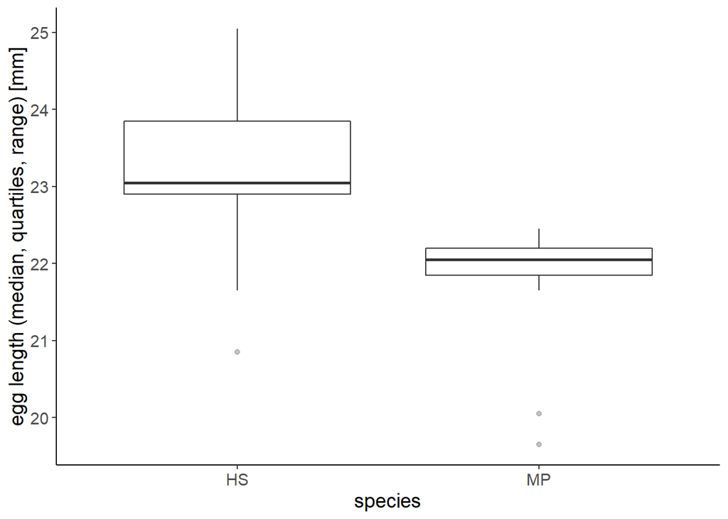

```r
cuckoos2_plot <- ggplot(data = cuckoos2, mapping = aes(x = Species, y = EggL)) +
  geom_boxplot(alpha = 0.3) + theme_classic() + theme(text = element_text(size = 14)) +
  labs(x = "species", y = "egg length (median, quartiles, range) [mm]")
plot(cuckoos2_plot)
```

```r
shapiro.test(cuckoos2a$EggL)
```

```
##
##  Shapiro-Wilk normality test
##
## data:  cuckoos2a$EggL
## W = 0.94843, p-value = 0.5366
```

```r
shapiro.test(cuckoos2b$EggL)
```

```
##
##  Shapiro-Wilk normality test
##
## data:  cuckoos2b$EggL
## W = 0.68122, p-value = 0.0002377
```

Wariancja:  
Test na wariancje daje wynik p-value dużo większy niż 0,05- spełniony warunek homogeniczności wariancji.

```r
var.test(EggL ~ Species, data = cuckoos2)
```

```
##
##  F test to compare two variances
##
## data:  EggL by Species
## F = 1.604, num df = 13, denom df = 13, p-value = 0.4055
## alternative hypothesis: true ratio of variances is not equal to 1
## 95 percent confidence interval:
##  0.5149258 4.9965557
## sample estimates:
## ratio of variances
##           1.604012
```

**Test t-studenta:**

```r
t.test(EggL ~ Species, data = cuckoos2, var.equal = T)
```

```
##
##  Two Sample t-test
##
## data:  EggL by Species
## t = 3.7291, df = 26, p-value = 0.0009438
## alternative hypothesis: true difference in means is not equal to 0
## 95 percent confidence interval:
##  0.6090629 2.1052228
## sample estimates:
## mean in group HS mean in group MP
##         23.12143         21.76429
```

**Test ANOVA:**

```r
summary(ANOVA_cu <- aov(EggL ~ Species, cuckoos2))
```

```
##             Df Sum Sq Mean Sq F value   Pr(>F)
## Species      1  12.89  12.893   13.91 0.000944 ***
## Residuals   26  24.11   0.927
## ---
## Signif. codes:  0 '***' 0.001 '**' 0.01 '*' 0.05 '.' 0.1 ' ' 1
```

Zarówno test t-studenta wartość p-value i jej odpowiednik z testu ANOVA Pr(>F) wynoszą 0.0009438, zatem należy odrzucić hipotezę zerową i przyjąć hipotezę alternatywną, że:  
**Średnia długość jaj kukułki jest różna w gnieździe świergotka łąkowego i płochacza pokrzywnica.**

**Rozkład reszt oraz wykresy obrazujące wyniki:**

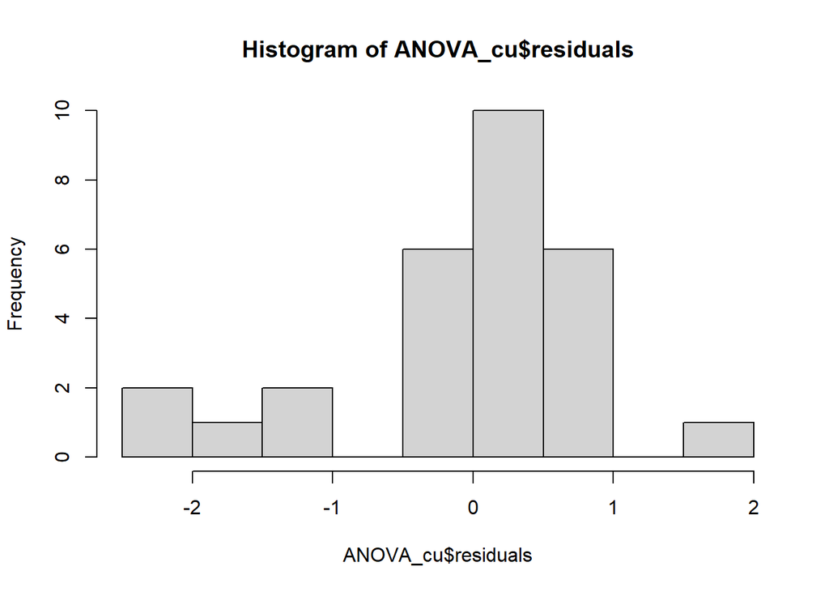

```r
hist(ANOVA_cu$residuals)
```

```r
shapiro.test(ANOVA_cu$residuals)
```

```
##
##  Shapiro-Wilk normality test
##
## data:  ANOVA_cu$residuals
## W = 0.87581, p-value = 0.00325
```

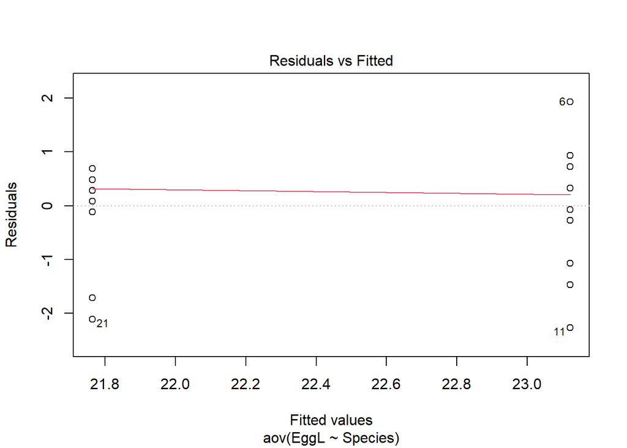

```r
plot(ANOVA_cu,1)
```

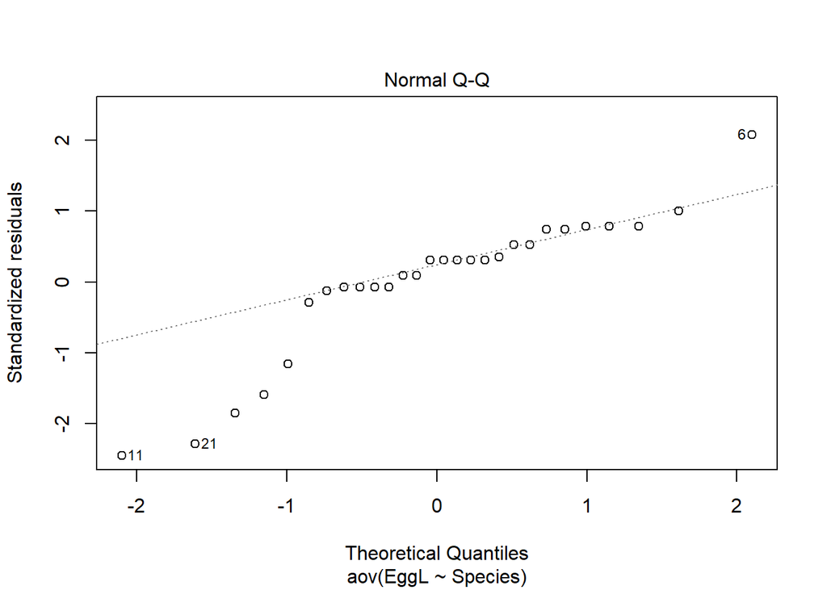

```r
plot(ANOVA_cu,2)
```

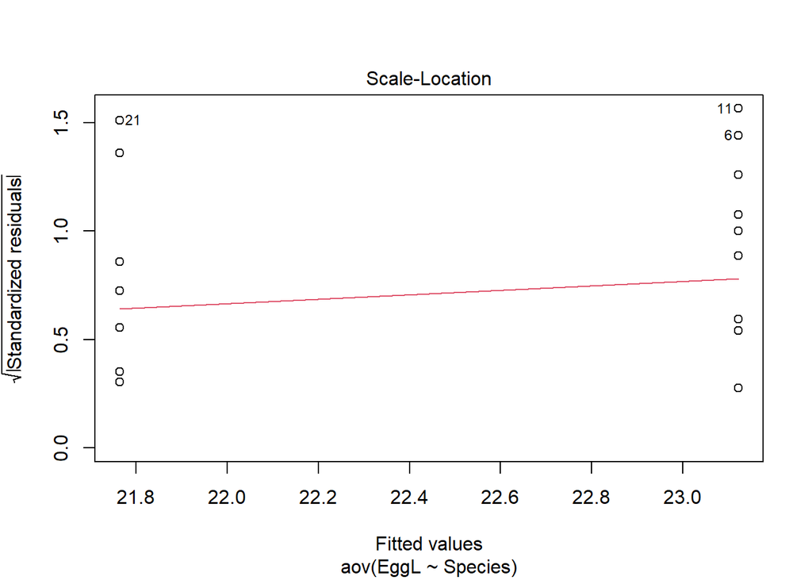

```r
plot(ANOVA_cu,3)
```

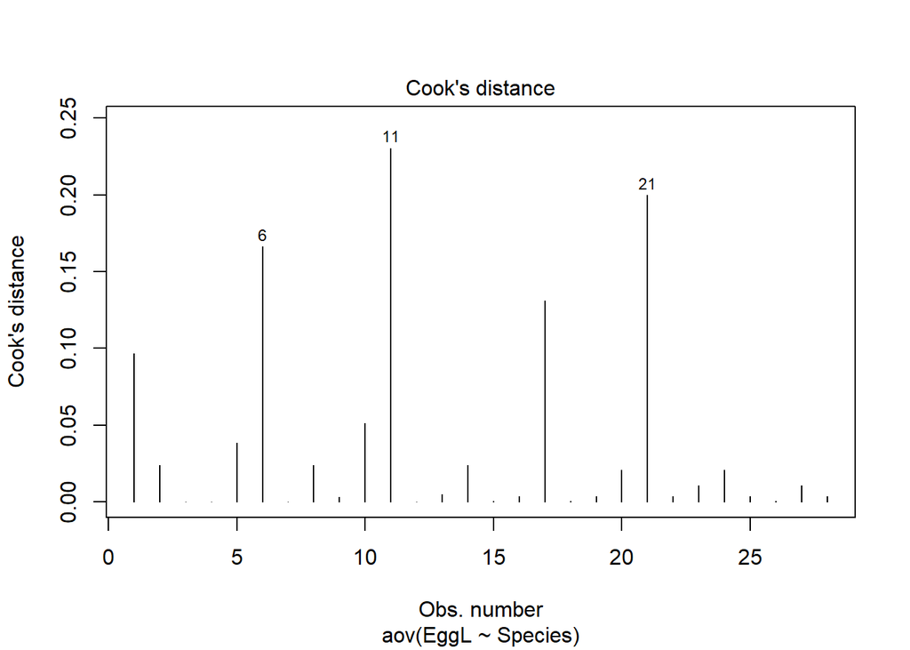

```r
plot(ANOVA_cu,4)
```

## Zadanie 2

**Hipoteza robocza:**

Średnia długość jaj kukułki jest różna w gniazdach przedstawionych gatunków.

**Hipoteza zerowa:**

Średnia długość jaj kukułki nie różni się w gniazdach przedstawionych gatunków.

**Hipoteza alternatywna:**

Średnia długość jaj kukułki jest różna w gniazdach przedstawionych gatunków.

**Testy “z wyboru”:**

Testu ANOVA dla grup.

**Założenia teoretycznie dotyczące rozkładu wymagane dla wybranego testu:**

Rozkład zbliżony do normalnego. Homogeniczność wariancji między grupami.

**Statystyki opisowe:**

```r
cuckoos6 <- read.table(file = "Cuckoos_6.txt",
                        sep = "\t",
                        header = T,
                        stringsAsFactors = T)
cuckoos6 %>% group_by(Species) %>%
  summarize(mean = mean(EggL), median = median(EggL),
            maximum = max(EggL), minimum = min(EggL),
            sd = sd(EggL), N = length(EggL))
```

```
## # A tibble: 6 x 7
##   Species  mean median maximum minimum    sd     N
##   <fct>   <dbl>  <dbl>   <dbl>   <dbl> <dbl> <int>
## 1 HS       23.1   23.0    25.0    20.8 1.07     14
## 2 MP       21.8   22.0    22.4    19.6 0.844    14
## 3 PW       22.8   22.8    24.8    21.0 1.06     14
## 4 R        22.6   22.8    23.8    21.0 0.728    14
## 5 TP       23.2   23.4    24.0    21.0 0.865    14
## 6 W        21.1   21.0    22.2    19.8 0.771    14
```

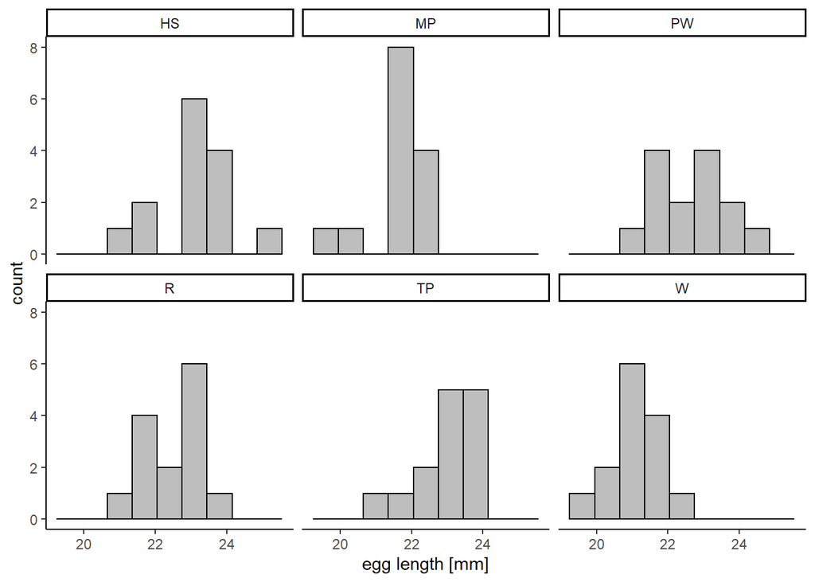

```r
hist_cuckoos6 <- ggplot(cuckoos6, aes(x = EggL)) +
  geom_histogram(binwidth=0.7, colour="black", fill="grey") +
  facet_wrap(~Species, scales="fixed")+ theme_classic() + xlab("egg length [mm]")
plot(hist_cuckoos6)
```

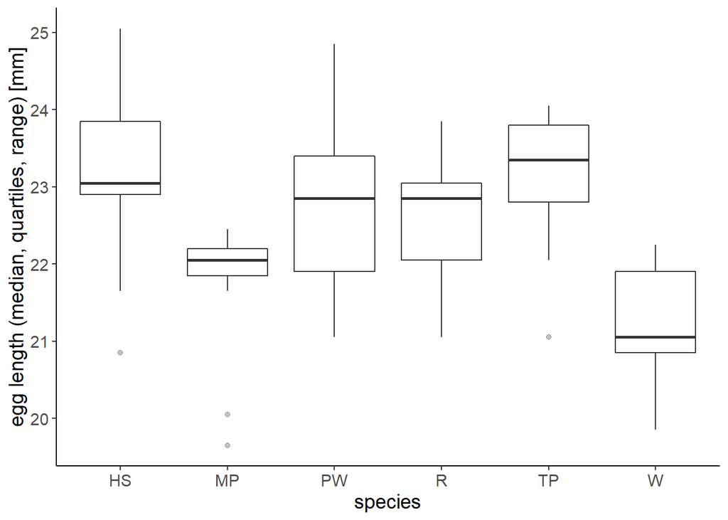

```r
cuckoos6_plot <- ggplot(data = cuckoos6, mapping = aes(x = Species, y = EggL)) +
  geom_boxplot(alpha = 0.3) + theme_classic() + theme(text = element_text(size = 14)) +
  labs(x = "species", y = "egg length (median, quartiles, range) [mm]")
plot(cuckoos6_plot)
```

**Założenia teoretyczne:**  
Rozkład:  
Przeprowadzanie testu Shapiro nie ma specjalnie sensu dla tak małej liczby danych, tym bardziej, że badamy jednocześnie 6 grup. Z histogramów widać, że rozkład jest zbliżony do normalnego dla wszystkich zestawów danych. Występują tylko cztery nieznaczne outlayery, tym samym można przyjąć, że warunek normalności rozkładu jest spełniony.

Wariancja:  
Test Bartletta na wariancje daje wynik p-value dużo większy niż 0,05- spełniony warunek homogeniczności wariancji.

```r
bartlett.test(EggL ~ Species, cuckoos6)
```

```
##
##  Bartlett test of homogeneity of variances
##
## data:  EggL by Species
## Bartlett's K-squared = 3.2443, df = 5, p-value = 0.6624
```

**Test ANOVA:**

```r
summary(ANOVA_cu6 <- aov(EggL ~ Species, cuckoos6))
```

```
##             Df Sum Sq Mean Sq F value   Pr(>F)
## Species      5  46.77   9.355   11.58 2.22e-08 ***
## Residuals   78  63.01   0.808
## ---
## Signif. codes:  0 '***' 0.001 '**' 0.01 '*' 0.05 '.' 0.1 ' ' 1
```

Odpowiednik p-value z testu ANOVA- Pr(>F) wynosi 2.22e-08, zatem należy odrzucić hipotezę zerową i przyjąć hipotezę alternatywną, że:  
**Średnia długość jaj kukułki jest różna w gniazdach przedstawionych gatunków.**

**Rozkład reszt oraz wykresy obrazujące wyniki:**

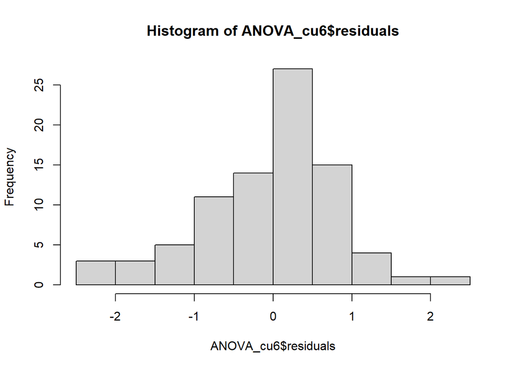

```r
hist(ANOVA_cu6$residuals)
```

Wykres wskazuje na rozkład zbliżony do normalnego.

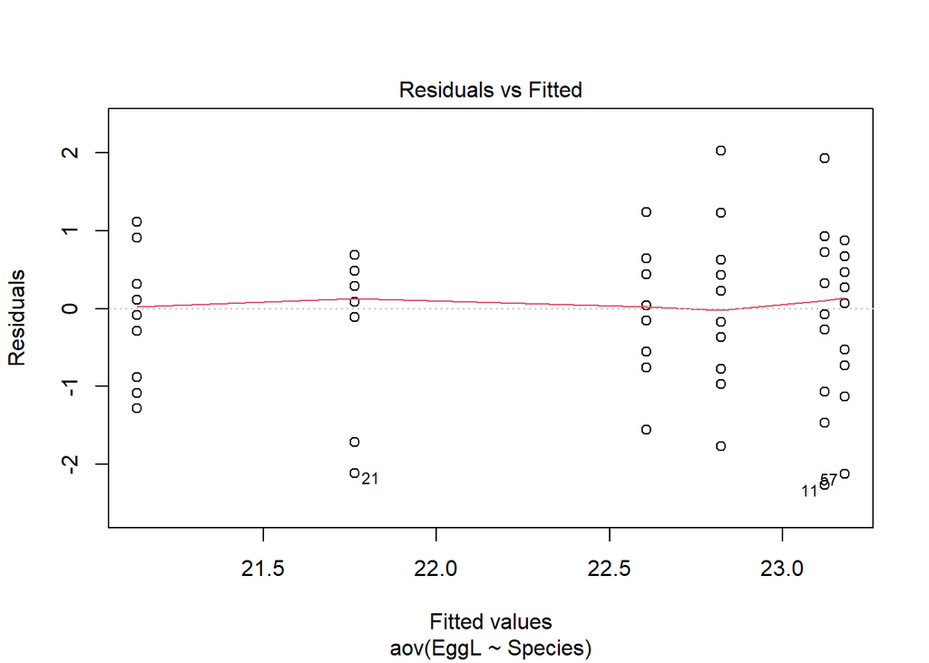

```r
plot(ANOVA_cu6,1)
```

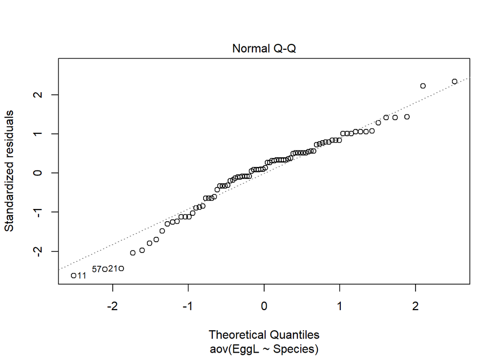

```r
plot(ANOVA_cu6,2)
```

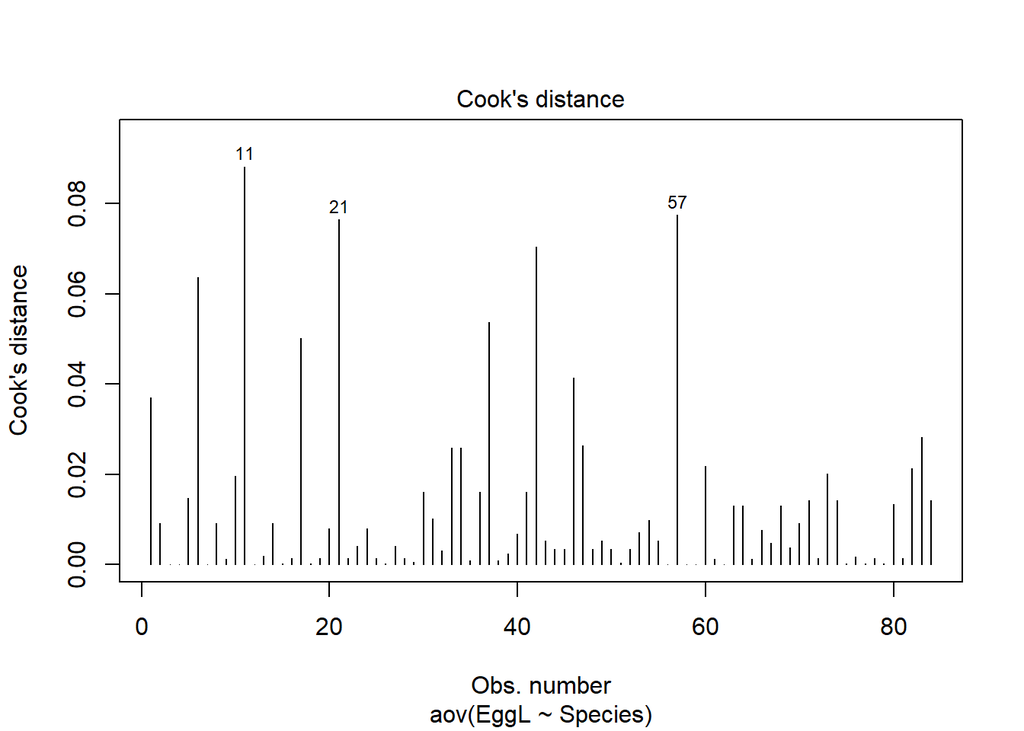

```r
plot(ANOVA_cu6,4)
```

Wnioski z wykresów:  
Rozkład jest bardzo zbliżony do normalnego, wartości wariancji są bardzo zbliżone do siebie, istniejące outlayery nie maja praktycznie żadnego wpływu na wynik testu.

## Zadanie 3

**Hipoteza robocza:**

Średnia przeżywalność przy chorobach nowotworowych różni się w zależności od narządu, w którym rozwija się nowotwór.

**Hipoteza zerowa:**

Średnia przeżywalność przy chorobach nowotworowych nie różni się w zależności od narządu, w którym rozwija się nowotwór.

**Hipoteza alternatywna:**

Średnia przeżywalność przy chorobach nowotworowych różni się w zależności od narządu, w którym rozwija się nowotwór.

**Testy “z wyboru”:**

Test ANOVA dla grup.

**Założenia teoretycznie dotyczące rozkładu wymagane dla wybranego testu:**

Rozkład zbliżony do normalnego. Homogeniczność wariancji między grupami.

**Statystyki opisowe:**

```r
cancer <- read.table(file = "Cancer.txt",
                        sep = "\t",
                        header = T,
                        stringsAsFactors = T)
cancer %>% group_by(Organ) %>%
  summarize(mean = mean(Survival), median = median(Survival),
            maximum = max(Survival), minimum = min(Survival),
            sd = sd(Survival), N = length(Survival))
```

```
## # A tibble: 5 x 7
##   Organ     mean median maximum minimum    sd     N
##   <fct>    <dbl>  <dbl>   <int>   <int> <dbl> <int>
## 1 Breast   1396.   1166    3808      24 1239.    11
## 2 Bronchus  212.    155     859      20  210.    17
## 3 Colon     457.    372    1843      20  427.    17
## 4 Ovary     884.    406    2970      89 1099.     6
## 5 Stomach   286     124    1112      25  346.    13
```

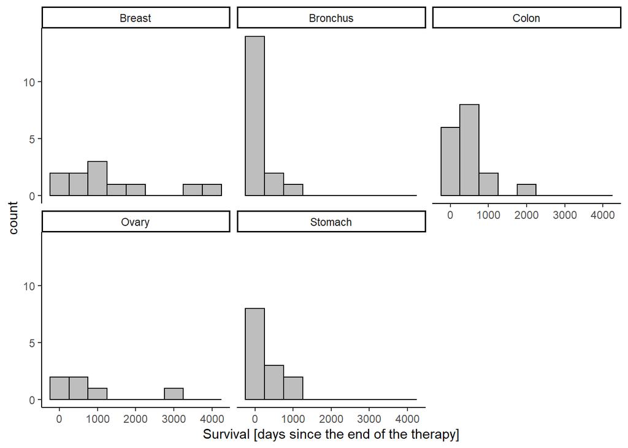

```r
hist_cancer <- ggplot(cancer, aes(x = Survival)) +
  geom_histogram(binwidth=500, colour="black", fill="grey") +
  facet_wrap(~Organ, scales="fixed")+ theme_classic() + xlab("Survival [days since the end of the therapy]")
plot(hist_cancer)
```

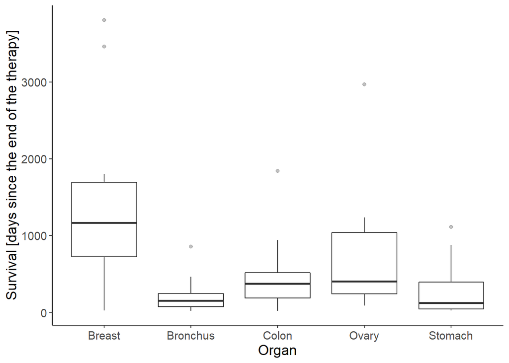

```r
cancer_plot <- ggplot(data = cancer, mapping = aes(x = Organ, y = Survival)) +
  geom_boxplot(alpha = 0.3) + theme_classic() + theme(text = element_text(size = 14)) +
  labs(x = "Organ", y = "Survival [days since the end of the therapy]")
plot(cancer_plot)
```

**Założenia teoretyczne:**  
Rozkład:  
Przeprowadzanie testu Shapiro nie ma specjalnie sensu dla tak małej liczby danych, tym bardziej, że badamy jednocześnie 5 grup. Z histogramów widać, że rozkład nie jest zbliżony do normalnego dla wszystkich zestawów danych. Występuje też 6 nieznacznych outlayerów.  
Próba rozwiązania: transformacja logarytmiczna:

```r
cancer2 <- cancer
cancer2$Survival <- log10(cancer$Survival)
```

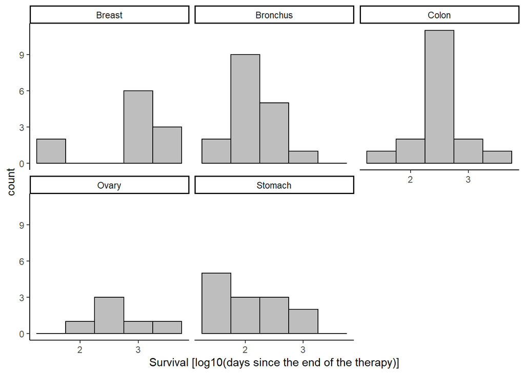

```r
hist_cancer2 <- ggplot(cancer2, aes(x = Survival)) +
  geom_histogram(binwidth=0.5, colour="black", fill="grey") +
  facet_wrap(~Organ, scales="fixed")+ theme_classic() + xlab("Survival [log10(days since the end of the therapy)]")
plot(hist_cancer2)
```

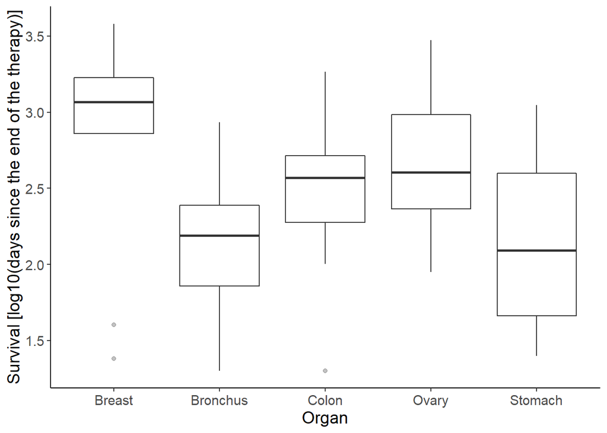

```r
cancer_plot2 <- ggplot(data = cancer2, mapping = aes(x = Organ, y = Survival)) +
  geom_boxplot(alpha = 0.3) + theme_classic() + theme(text = element_text(size = 14)) +
  labs(x = "Organ", y = "Survival [log10(days since the end of the therapy)]")
plot(cancer_plot2)
```

Rozkład:  
Teraz zbliżony do normalnego dla wszystkich grup.  
Wariancja:  
Test Bartletta na wariancje daje wynik p-value dużo większy niż 0,05- spełniony warunek homogeniczności wariancji.

```r
bartlett.test(Survival ~ Organ, cancer2)
```

```
##
##  Bartlett test of homogeneity of variances
##
## data:  Survival by Organ
## Bartlett's K-squared = 4.809, df = 4, p-value = 0.3075
```

**Test ANOVA:**

```r
summary(ANOVA_can <- aov(Survival ~ Organ, cancer2))
```

```
##             Df Sum Sq Mean Sq F value  Pr(>F)
## Organ        4  4.618  1.1546   4.286 0.00412 **
## Residuals   59 15.894  0.2694
## ---
## Signif. codes:  0 '***' 0.001 '**' 0.01 '*' 0.05 '.' 0.1 ' ' 1
```

Odpowiednik p-value z testu ANOVA- Pr(>F) wynosi 0.00412, zatem należy odrzucić hipotezę zerową i przyjąć hipotezę alternatywną, że:  
**Średnia przeżywalność przy chorobach nowotworowych różni się w zależności od narządu, w którym rozwija się nowotwór.**

**Rozkład reszt oraz wykresy obrazujące wyniki:** Z histogramów widać przerwy w rozkładzie. Można dokonać ograniczenia wyników do Survivability < 2000 w celu otrzymania ciągłego rozkładu.

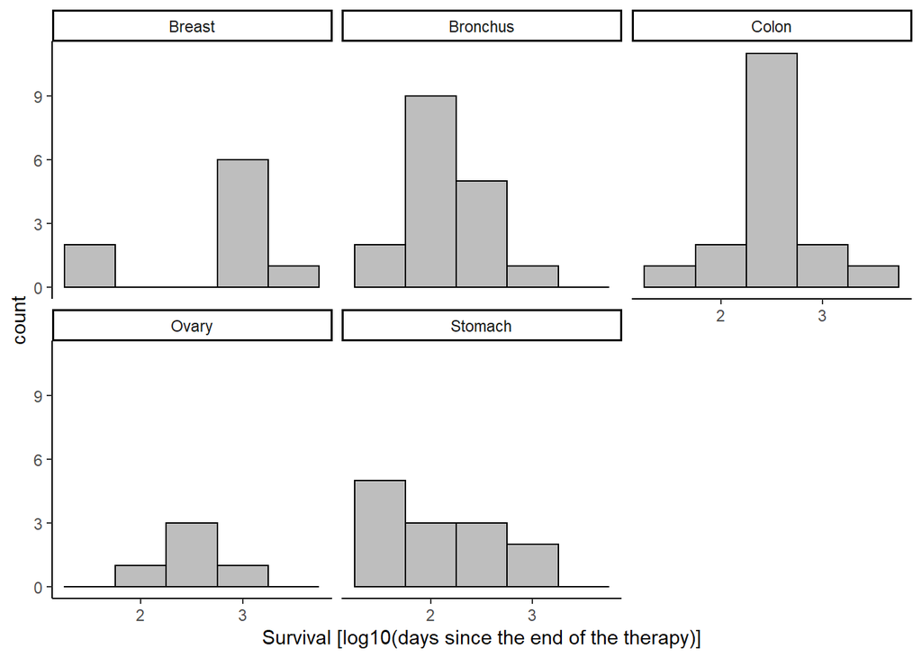

```r
cancer3 <- subset(cancer, Survival < 2000)
cancer3$Survival <- log10(cancer3$Survival)
hist_cancer3 <- ggplot(cancer3, aes(x = Survival)) +
  geom_histogram(binwidth=0.5, colour="black", fill="grey") +
  facet_wrap(~Organ, scales="fixed")+ theme_classic() + xlab("Survival [log10(days since the end of the therapy)]")
plot(hist_cancer3)
```

```r
bartlett.test(Survival ~ Organ, cancer3)
```

```
##
##  Bartlett test of homogeneity of variances
##
## data:  Survival by Organ
## Bartlett's K-squared = 4.0081, df = 4, p-value = 0.4049
```

```r
summary(ANOVA_canc <- aov(Survival ~ Organ, cancer3))
```

```
##             Df Sum Sq Mean Sq F value Pr(>F)
## Organ        4  2.688  0.6719    2.71 0.0391 *
## Residuals   56 13.885  0.2479
## ---
## Signif. codes:  0 '***' 0.001 '**' 0.01 '*' 0.05 '.' 0.1 ' ' 1
```

Wyniki są analogiczne do wyników dla wyłącznie zlogarytmowanych danych.

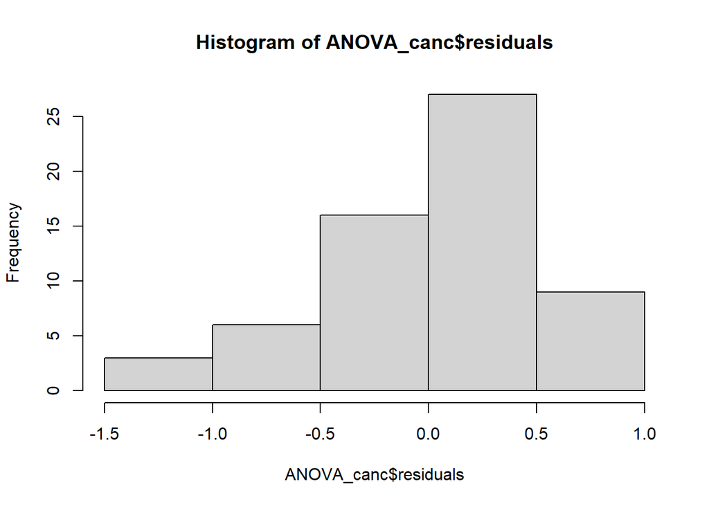

```r
hist(ANOVA_canc$residuals)
```

Wykres wskazuje na rozkład zbliżony do normalnego.

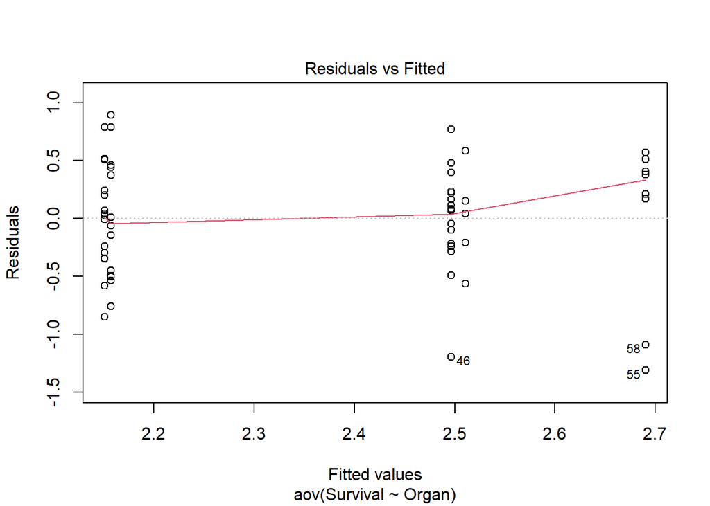

```r
plot(ANOVA_canc,1)
```

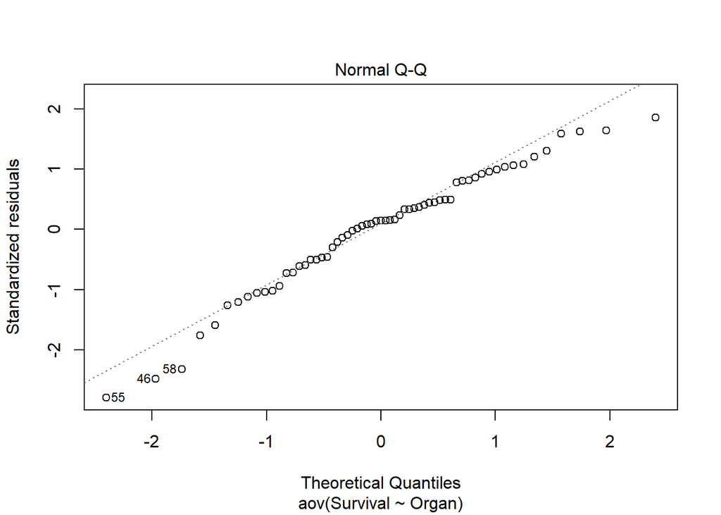

```r
plot(ANOVA_canc,2)
```

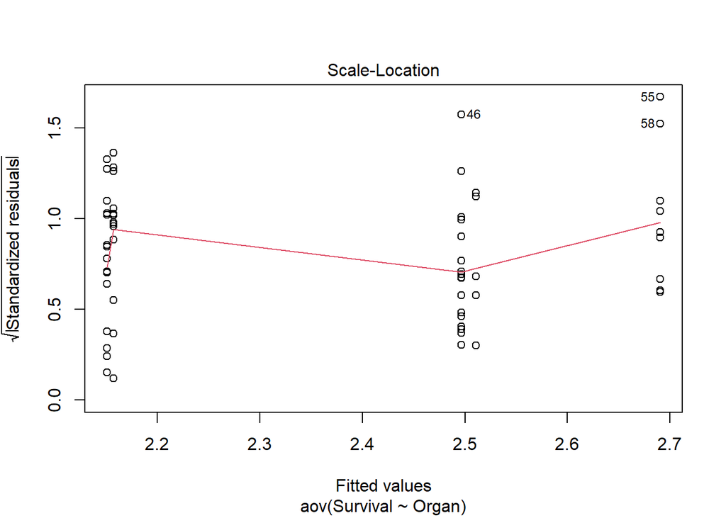

```r
plot(ANOVA_canc,3)
```

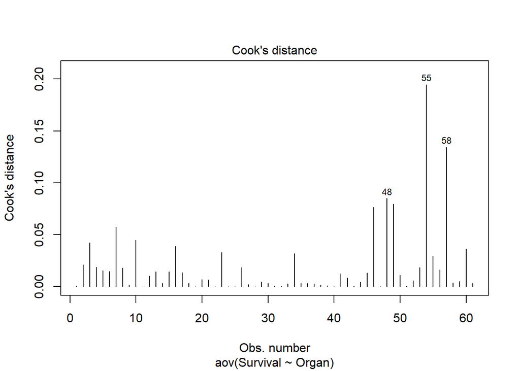

```r
plot(ANOVA_canc,4)
```

Wnioski z wykresów:  
Rozkład jest bardzo zbliżony do normalnego, wartości wariancji są zbliżone do siebie, istniejące outlayery mają znikomy wpływ na wynik testu.